# The White House is UGH

Ben Brennan

5/8/2020

So, a few days ago, the old Chairman of the Council of Economic Advisers for Trump tried to tell the country that, according to his “cubic” model, we would be looking at [0 new COVID-19 deaths(!!)](https://www.washingtonpost.com/health/government-report-predicts-covid-19-cases-will-reach-200000-a-day-by-june-1/2020/05/04/02fe743e-8e27-11ea-a9c0-73b93422d691_story.html) by around May 15th, 2020. This is - obviously and unpredictably - not correct. In an update, it turns out the “cubic” model was a [canned Excel function](https://www.businessinsider.com/trump-advisor-kevin-hassett-excel-function-cubic-model-coronavirus-2020-5). Is anyone surprised Trump and friends are relying on clicking random buttons to make life or death decisions at this point?

Let’s look at why this model is bad, and more generally why prediction is harder than pressing buttons in Excel.

We are going to fit 3 models on the new death data from the [Covid Tracking Project](https://covidtracking.com/) - a linear model (go stats!), a cubic model (hire me, trump!) and a higher order polynomial model (hey check me out I am smart!).

P.S we do all this “linearly” when it comes to statistics, so.. statisticians *FTW*.

```r
library(jsonlite); library(ggplot2); library(dplyr); library(tidyr)

covid <- fromJSON("https://covidtracking.com/api/v1/us/daily.json")

covid$day = order(1:nrow(covid), decreasing = T)

covid <- covid %>% filter(day > 50) %>% arrange(day)

linear.model <- lm(deathIncrease ~ day, data = covid)

# 1 - sum(linear.model$residuals^2) / sum((covid$deathIncrease - mean(covid$deathIncrease))^2)
summary(linear.model)$r.squared
```

```
## [1] 0.6780335
```

```r
shitty.model = lm(deathIncrease ~ day + I(day^2) + I(day^3), data = covid)

summary(shitty.model)$r.squared
```

```
## [1] 0.7896855
```

```r
shitty.model2 = lm(deathIncrease ~ day + I(day^2) + I(day^3) + I(day^4) + I(day^5), data = covid)

summary(shitty.model2)$r.squared
```

```
## [1] 0.8534636
```

Looks like, from a preliminary analysis, the $R^2$ from the higher order polynomial (which I chose to have order 5 because why not?) is the highest. So we should pick this one, right Kevin?

No. Why? Because I can add a buncha terms to my model and $R^2$ would go up (because adding explanatory variables can’t take away from the explanatory power of your model. Might not help that much, but). Adding a bunch of explanatory variables (higher order polynomials, in this case) leads to what is called *overfitting*. Your model fits the data that you have very well, but it does very poor on data that it has not seen before. This is related intrinsically to the bias-variance trade-off we see.

Let’s look at the curves we are looking at.

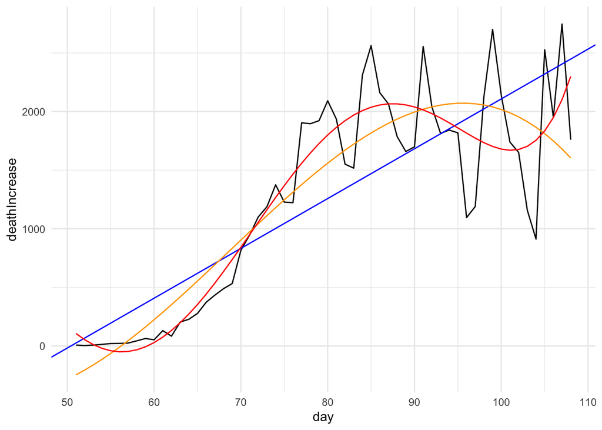

```r
covid$bad.prediction <- predict(shitty.model, newdata = covid)
covid$bad.prediction2 <- predict(shitty.model2, newdata = covid)

death.plot.bad <- covid %>% ggplot(aes(x =day, y = deathIncrease)) + geom_line() + geom_abline(intercept = linear.model$coefficients[1], slope = linear.model$coefficients[2], color = "blue") + theme_minimal() + geom_line(aes(x = day, y = bad.prediction), color = "orange") + geom_line(aes(x = day, y = bad.prediction2), color = "red")

death.plot.bad
```

The orange is presumably what the white house was using (he-he), the blue is the linear model, and the red is the 5-th order polynomial. All look to fit the data here decently yeah? But what happens if we try to extrapolate?

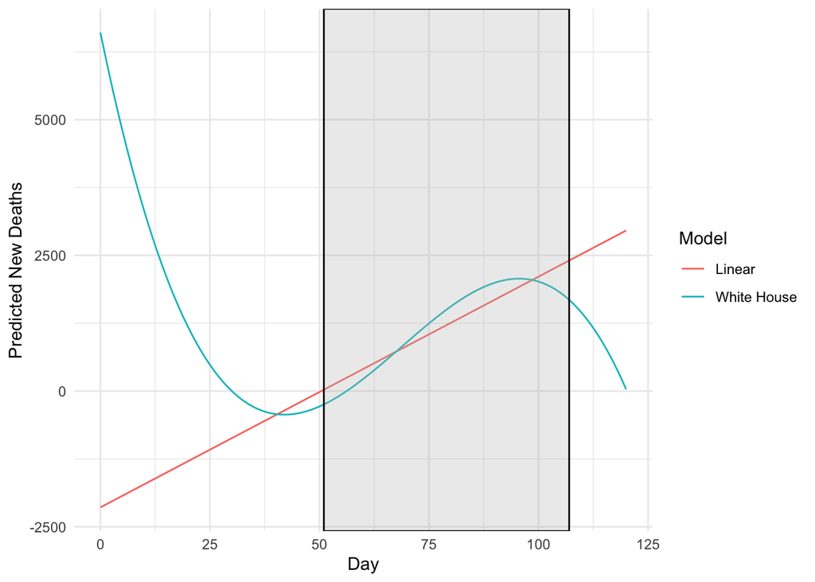

```r
extrapolation <- data.frame(0:120,
                            predict(linear.model, data.frame(day = 0:120)),
                            predict(shitty.model, data.frame(day = 0:120)),
                            predict(shitty.model2, data.frame(day = 0:120)))



names(extrapolation) <- c("day", "linear", "wh", "way.overfit")

extrapolation <- extrapolation %>% pivot_longer(-day,names_to = "model", values_to = "pred_deaths")
rect <- data.frame(xmin = 51, xmax = 107, ymin = -Inf, ymax = Inf)



extrapolate.plot1 <- extrapolation %>%
  filter(model != "way.overfit") %>%
  ggplot(aes(x = day, y = pred_deaths, color = model)) +
  geom_line() +
  scale_color_discrete(name = "Model", labels = c(linear = "Linear",
                                                  #way.overfit = "Overfit",
                                                  wh = "White House")) +
  geom_rect(data = rect, inherit.aes = F, aes(xmin = xmin, xmax = xmax, ymin = ymin, ymax = ymax),
           color = "black", fill = "grey", alpha = 0.3) +
  theme_minimal() + ylab("Predicted New Deaths") + xlab("Day") +
  NULL

extrapolate.plot1
```

No we are seeing some big differences. The grey area shows that range of data that we used for our model, the rest is data the model has never “seen” and is demonstrably false in both cases. We had negative deaths when the data started being recorded (linear model)? Or did we have thousands of new deaths a day, but decreasing (white house)? So if we can’t use them going backwards, should we trust either of them moving forward? Probably not. Is one more reliable than the other? I don’t know. I assume both aren’t very good, and we will talk about why.

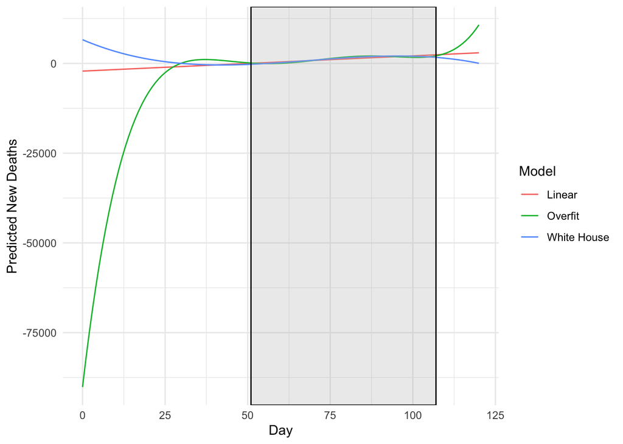

```r
extrapolate.plot2 <- extrapolation %>%
  #filter(model != "way.overfit") %>%
  ggplot(aes(x = day, y = pred_deaths, color = model)) +
  geom_line() +
  scale_color_discrete(name = "Model", labels = c(linear = "Linear",
                                                 way.overfit = "Overfit",
                                                  wh = "White House")) +
  geom_rect(data = rect, inherit.aes = F, aes(xmin = xmin, xmax = xmax, ymin = ymin, ymax = ymax),
           color = "black", fill = "grey", alpha = 0.3) +
  theme_minimal() + ylab("Predicted New Deaths") + xlab("Day") +
  NULL

extrapolate.plot2
```

Now, including the 5-th order polynomial, we see the predictions are, like, ridiculous. But I sounded smart making a 5-th order polynomial and so would Trump if he spat that at some reporter so let’s not put it out of the range of possibilities. What is wrong with this model is it is really overfit. It fits the data it has seen very well, but has literally no idea what is going on outside of that. Or, at least, its much more uncertain about the unknowns.

### So why is this bad?

Primarily, the data is overly simplistic (and totally incomplete). We are aggregating all the death cases from the whole country, where there are significantly different things happening. I am in SE Michigan - we have a lot of cases, but they are decreasing. We are advised to not go outside. People don’t go outside. I am from NM, where cases are on the rise but there aren’t a lot, people are advised to not go outside but people still do because they’re idiots. I am not in GA nor am I from there (thank god), but that’s an absolute wildcard. Case in point - a canned analysis like this sucks.

Second, from a statistical standpoint, we assume a lot of things but, importantly in this case, when we fit these curves with simple methods like this we assume the outcomes are *independent*. This is wrong. The number of deaths today obviously depends on the number of deaths yesterday. There are methods to deal with this - but using a canned Excel function does not do this. Another problem here is the number of deaths is always positive, so modeling this linearly doesn’t make sense when it comes to predictions. It is okay, in my opinion, to do in the range of the data you have if you plan to make claims about the relationship between the two variables and *not* extrapolate - which we are not doing in this case. You could log transform the data (turns out I think White House seems to have done [exactly that](https://twitter.com/LucyStats/status/1257787850260656128), but this again doesn’t fix any of the above problems.

Third, and like I have said, prediction is *wicked hard* in this case. Pretending you know what you are doing when you do not is bad, and much worse when your ignorance advises real policy. I’m a PhD student in biostatistics and, while I know some methods to deal with the above problems, I am not going to pretend I have any idea what tomorrow will look like.

**Continue to listen to experts, because they are the ones who know how to model this correctly**. And don’t use Excel to model and predict global pandemics like a 1st year frat boy business student. Unless you want a job at the White House right now?